# DS3 projects

## Displaying fear and positive searches by state between 2004 and 2020

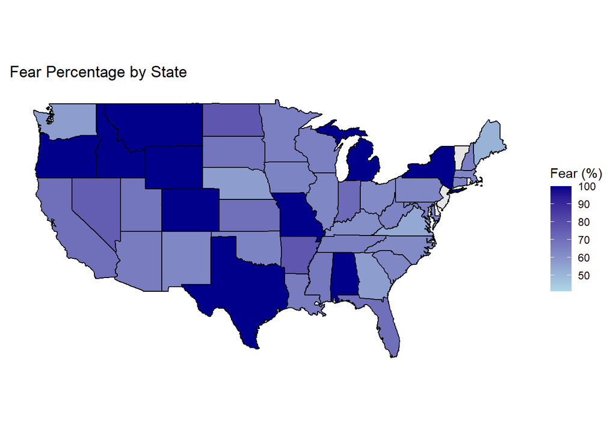

```r
# Pre-processing map data which includes metro area
map <- map %>%
  mutate(
    state = str_extract(Metro, "[A-Z]{2}$"),
    fear = as.numeric(str_replace(fear, "%", "")),
    success = as.numeric(str_replace(success, "%", ""))
  )


# state abbreviation to correlate with the ones given and mutate into full state names for accurate plotting
state_abbreviations <- data.frame(
  abbreviation = c(
    "AL", "AK", "AZ", "AR", "CA", "CO", "CT", "DE", "FL", "GA",
    "HI", "ID", "IL", "IN", "IA", "KS", "KY", "LA", "ME", "MD",
    "MA", "MI", "MN", "MS", "MO", "MT", "NE", "NV", "NH", "NJ",
    "NM", "NY", "NC", "ND", "OH", "OK", "OR", "PA", "RI", "SC",
    "SD", "TN", "TX", "UT", "VT", "VA", "WA", "WV", "WI", "WY"
  ),
  state = tolower(c(
    "Alabama", "Alaska", "Arizona", "Arkansas", "California",
    "Colorado", "Connecticut", "Delaware", "Florida", "Georgia",
    "Hawaii", "Idaho", "Illinois", "Indiana", "Iowa", "Kansas",
    "Kentucky", "Louisiana", "Maine", "Maryland", "Massachusetts",
    "Michigan", "Minnesota", "Mississippi", "Missouri", "Montana",
    "Nebraska", "Nevada", "New Hampshire", "New Jersey", "New Mexico",
    "New York", "North Carolina", "North Dakota", "Ohio", "Oklahoma",
    "Oregon", "Pennsylvania", "Rhode Island", "South Carolina",
    "South Dakota", "Tennessee", "Texas", "Utah", "Vermont",
    "Virginia", "Washington", "West Virginia", "Wisconsin", "Wyoming"
  ))
)

# mutating data
map2 <- map %>%
  left_join(state_abbreviations, by = c("state" = "abbreviation")) %>%
  rename(region = state.y)

# obtaining and converting necessary map data
states_map <- map_data("state")
map_data <- left_join(states_map, map2, by = "region") |>  mutate(success = ifelse(is.na(success), 0, success))

# plotting fear searches
ggplot(map_data, aes(x = long, y = lat, group = group, fill = fear)) +
  geom_polygon(color = "black") +
  scale_fill_gradient(name = "Fear (%)", low = "lightblue", high = "darkblue", na.value = "grey90") +
  coord_fixed(1.3) +
  ggtitle("Fear Percentage by State") +
  theme(axis.title = element_blank(), axis.text =  element_blank(),, axis.ticks =  element_blank(), panel.background = element_blank())
```

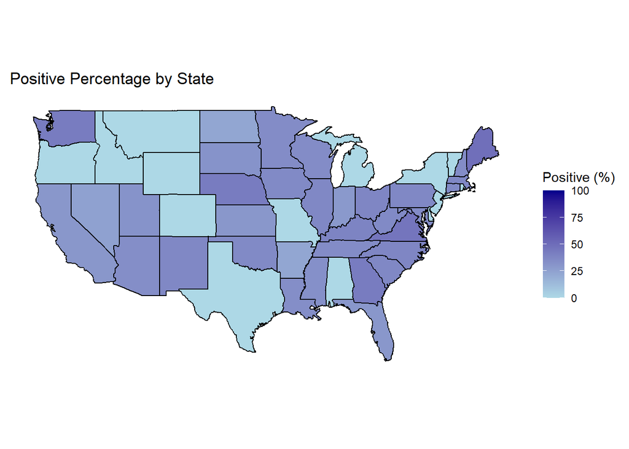

```r
# plotting positive searches
ggplot(map_data, aes(x = long, y = lat, group = group, fill = success)) +
  geom_polygon(color = "black") +
  scale_fill_gradient(name = "Positive (%)", low = "lightblue", high = "darkblue", na.value = "grey90") +
  coord_fixed(1.3) +
  ggtitle("Positive Percentage by State") +
  theme(axis.title = element_blank(), axis.text =  element_blank(),, axis.ticks =  element_blank(), panel.background = element_blank())
```

**Figure 6.** *Search percentages by state*  
The plots display the percentage of fear and positive searches made by each state. The positive search percentages are simply an inversion on the fear searches. However, the second plot was made to more clearly see the correlation of searches by state. Upon first inspection nothing can be definitively seen in the plot other than more conservative states have higher fear based searches but not all. Their are a couple of liberal states that are also seen with higher fear searches. A deeper dive would have to be done to glean more information from the plot. For example, a look at the political divide in each state, population of immigrants by state, or perhaps a better view at the distribution over time instead of average searcvhes of a set of time.